# Лабораторная работа №5

Операционные системы

Лебеденко Е.В.

Российский университет дружбы народов, Москва, Россия

# Информация

## Докладчик

- Лебеденко Елена Викторовна
- Студент НКАбд-04-25
- Российский университет дружбы народов
- 1032253535@rudn.ru

# Цель работы

Познакомиься с менеджером паролей pass, научится управлению файлами конфигурации chezmoi, настроить рабочую среду.

# Задание

- Установить дополнительное ПО
- Установить и настроить pass
- Настроить интерфейс с браузером
- Сохранить пароль
- Установить и настроить chezmoi
- Настроить chezmoi на новой машине
- Выполнить ежедневные операции с chezmoi

# Теоретическое введение

Менеджер паролей pass хранит данные в файловой системе в виде каталогов и файлов, зашифрованных с помощью GPG-ключа. Структура базы паролей может быть произвольной при прямом использовании, но для работы с дополнительным ПО требуется задать семантику в структуре. chezmoi управляет файлами конфигурации домашнего каталога, сохраняя их состояние в ~/.local/share/chezmoi как клон репозитория dotfiles. Файлы конфигурации могут копироваться дословно или обрабатываться как шаблоны с учётом данных локальной машины из ~/.config/chezmoi/chezmoi.toml.

# Выполнение лабораторной работы

## Менеджер паролей pass

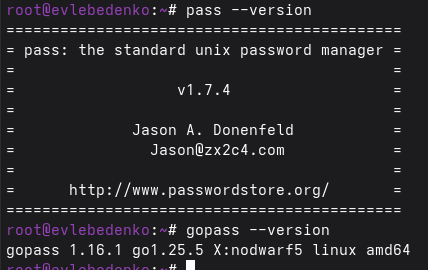

Установка pass

Инициализирую хранилище через ключ GPG, синхронизируюсь с git

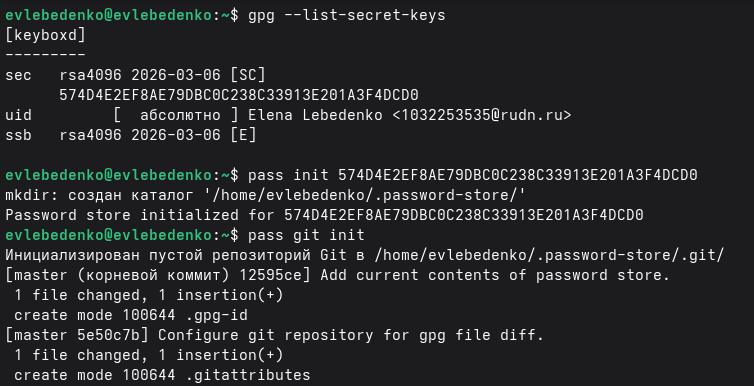

Инициализация хранилища

Отправляю данные на сервер

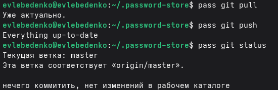

Отправка данных на сервер

## Настройка интерфейса с броузером

Установка native messaging

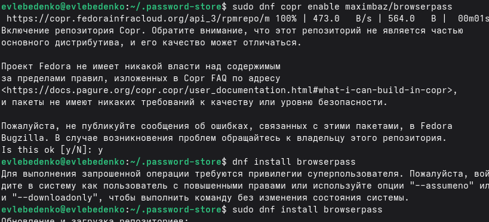

Установка native messaging

## Сохранение пароля

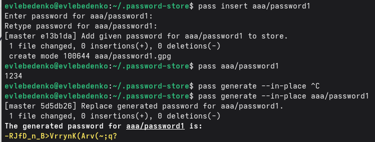

Работа с паролями

## Управление файлами конфигурации

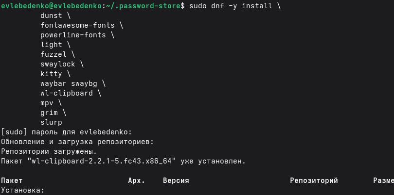

Установка дополнительное программное обеспечение

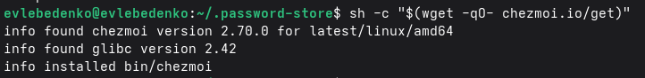

Установка бинарного файла

## Создание собственного репозитория с помощью утилит

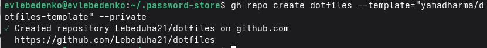

Создание репозитория

## Подключение репозитория к своей системе

Инициализирую chezmoi с моим репозиторием

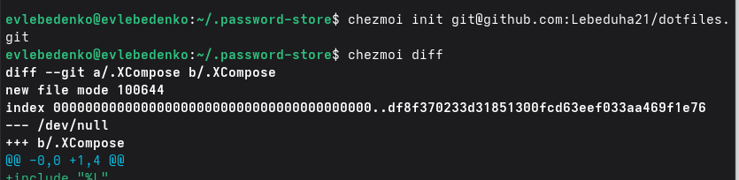

chezmoi

Извлекаю последние изменения из репозитория, проверяю и применяю их

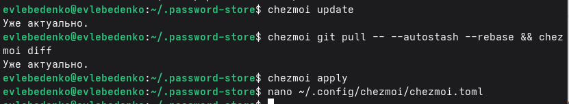

Ежедневные операции c chezmoi

# Выводы

Во время выполнения лабораторной работы я получила навыки правильной работы с репозиториями git.